# Week 14 IP dimensionality reduction

Njoki Mbugua

7/16/2021

```r
library(knitr)
```

# Defining the Question

## a) Specifying the Question

### c) Understanding the context

Working as a consultant Data analyst at Carrefour Kenya and are currently undertaking a project that will inform the marketing department on the most relevant marketing strategies that will result in the highest no. of sales (total price including tax).This project endeavors to explore a recent marketing dataset and perform dimensionality reduction using PCA method to determine the most important features that are best suited for predictive analysis.

### d) Recording the experimental design

Importing and reading the data Data Cleaning Implementing PCA. Conclusions and recommendations

### e) Data Relevance

The data was provided by the company(http://bit.ly/CarreFourDataset) from a recent marketing dataset.

# Loading and reading the data

```r
# Data url=http://bit.ly/CarreFourDataset

data = read.csv('http://bit.ly/CarreFourDataset',na.strings = "")
```

```r
# previewing the top 5 rows of the dataset
head(data,n=5)
```

```
##    Invoice.ID Branch Customer.type Gender           Product.line Unit.price
## 1 750-67-8428      A        Member Female      Health and beauty      74.69
## 2 226-31-3081      C        Normal Female Electronic accessories      15.28
## 3 631-41-3108      A        Normal   Male     Home and lifestyle      46.33
## 4 123-19-1176      A        Member   Male      Health and beauty      58.22
## 5 373-73-7910      A        Normal   Male      Sports and travel      86.31
##   Quantity     Tax      Date  Time     Payment   cogs gross.margin.percentage
## 1        7 26.1415  1/5/2019 13:08     Ewallet 522.83                4.761905
## 2        5  3.8200  3/8/2019 10:29        Cash  76.40                4.761905
## 3        7 16.2155  3/3/2019 13:23 Credit card 324.31                4.761905
## 4        8 23.2880 1/27/2019 20:33     Ewallet 465.76                4.761905
## 5        7 30.2085  2/8/2019 10:37     Ewallet 604.17                4.761905
##   gross.income Rating    Total
## 1      26.1415    9.1 548.9715
## 2       3.8200    9.6  80.2200
## 3      16.2155    7.4 340.5255
## 4      23.2880    8.4 489.0480
## 5      30.2085    5.3 634.3785
```

Loading the necessary libraries

```r
library(ggbiplot)
library("factoextra")
library(devtools)
library(dplyr)
# previewing the last five rows of the dataset
tail(data, n = 5)
```

```
##       Invoice.ID Branch Customer.type Gender        Product.line Unit.price
## 996  233-67-5758      C        Normal   Male   Health and beauty      40.35
## 997  303-96-2227      B        Normal Female  Home and lifestyle      97.38
## 998  727-02-1313      A        Member   Male  Food and beverages      31.84
## 999  347-56-2442      A        Normal   Male  Home and lifestyle      65.82
## 1000 849-09-3807      A        Member Female Fashion accessories      88.34
##      Quantity     Tax      Date  Time Payment   cogs gross.margin.percentage
## 996         1  2.0175 1/29/2019 13:46 Ewallet  40.35                4.761905
## 997        10 48.6900  3/2/2019 17:16 Ewallet 973.80                4.761905
## 998         1  1.5920  2/9/2019 13:22    Cash  31.84                4.761905
## 999         1  3.2910 2/22/2019 15:33    Cash  65.82                4.761905
## 1000        7 30.9190 2/18/2019 13:28    Cash 618.38                4.761905
##      gross.income Rating     Total
## 996        2.0175    6.2   42.3675
## 997       48.6900    4.4 1022.4900
## 998        1.5920    7.7   33.4320
## 999        3.2910    4.1   69.1110
## 1000      30.9190    6.6  649.2990
```

```r
# checking the number of rows and columnsin the dataset
dim(data)
```

```
## [1] 1000   16
```

```r
# the dataframe has 1000 rows and 16 columns
```

```r
# checking structure of the dataset
str(data)
```

```
## 'data.frame':    1000 obs. of  16 variables:
##  $ Invoice.ID             : chr  "750-67-8428" "226-31-3081" "631-41-3108" "123-19-1176" ...
##  $ Branch                 : chr  "A" "C" "A" "A" ...
##  $ Customer.type          : chr  "Member" "Normal" "Normal" "Member" ...
##  $ Gender                 : chr  "Female" "Female" "Male" "Male" ...
##  $ Product.line           : chr  "Health and beauty" "Electronic accessories" "Home and lifestyle" "Health and beauty" ...
##  $ Unit.price             : num  74.7 15.3 46.3 58.2 86.3 ...
##  $ Quantity               : int  7 5 7 8 7 7 6 10 2 3 ...
##  $ Tax                    : num  26.14 3.82 16.22 23.29 30.21 ...
##  $ Date                   : chr  "1/5/2019" "3/8/2019" "3/3/2019" "1/27/2019" ...
##  $ Time                   : chr  "13:08" "10:29" "13:23" "20:33" ...
##  $ Payment                : chr  "Ewallet" "Cash" "Credit card" "Ewallet" ...
##  $ cogs                   : num  522.8 76.4 324.3 465.8 604.2 ...
##  $ gross.margin.percentage: num  4.76 4.76 4.76 4.76 4.76 ...
##  $ gross.income           : num  26.14 3.82 16.22 23.29 30.21 ...
##  $ Rating                 : num  9.1 9.6 7.4 8.4 5.3 4.1 5.8 8 7.2 5.9 ...
##  $ Total                  : num  549 80.2 340.5 489 634.4 ...
```

```r
# previewing the column names
colnames(data)
```

```
##  [1] "Invoice.ID"              "Branch"
##  [3] "Customer.type"           "Gender"
##  [5] "Product.line"            "Unit.price"
##  [7] "Quantity"                "Tax"
##  [9] "Date"                    "Time"
## [11] "Payment"                 "cogs"
## [13] "gross.margin.percentage" "gross.income"
## [15] "Rating"                  "Total"
```

```r
# previewing the datatypes of the dataset columns
sapply(data,class)
```

```
##              Invoice.ID                  Branch           Customer.type
##             "character"             "character"             "character"
##                  Gender            Product.line              Unit.price
##             "character"             "character"               "numeric"
##                Quantity                     Tax                    Date
##               "integer"               "numeric"             "character"
##                    Time                 Payment                    cogs
##             "character"             "character"               "numeric"
## gross.margin.percentage            gross.income                  Rating
##               "numeric"               "numeric"               "numeric"
##                   Total
##               "numeric"
```

# Data cleaning

```r
# checking for missing values
sum(is.na(data))
```

```
## [1] 0
```

There are no missing values in the data set.

```r
# Checking for duplicated(data)
sum(duplicated(data))
```

```
## [1] 0
```

There are no duplicates in the data set.

```r
# Selecting numeric column
df <- select_if(data, is.numeric)
df
```

[output not shown]

[output cut: 1987 more lines]

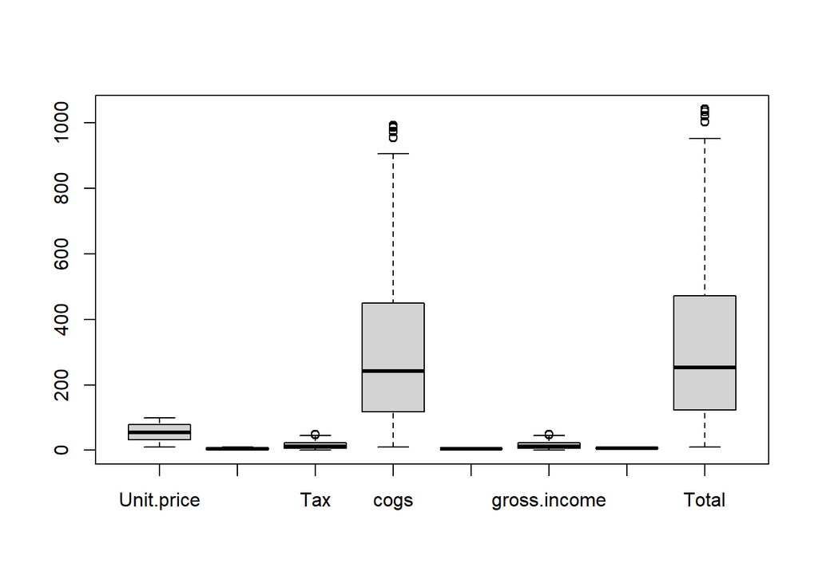

```r
# Using the boxplot to detect outliers in the numeric columns
boxplot(df)
```

Outliers were detected in the tax,cogs,gross income and total columns.

```r
# listing outliers
boxplot.stats(df$Tax)$out
```

```
## [1] 47.790 49.490 49.650 47.720 48.605 49.260 48.750 48.685 48.690
```

```r
boxplot.stats(df$cogs)$out
```

```
## [1] 955.8 989.8 993.0 954.4 972.1 985.2 975.0 973.7 973.8
```

```r
boxplot.stats(df$gross.income)$out
```

```
## [1] 47.790 49.490 49.650 47.720 48.605 49.260 48.750 48.685 48.690
```

```r
boxplot.stats(df$Total)$out
```

```
## [1] 1003.590 1039.290 1042.650 1002.120 1020.705 1034.460 1023.750 1022.385
## [9] 1022.490
```

The outliers were not removed since the values for this columns may vary extremely meaning that they are valid and important for analysis.

# Dimensionality reduction using PCA

```r
# Since PCA works on numeric variables lets view the numeric columns
head(df,n=3)
```

```
##   Unit.price Quantity     Tax   cogs gross.margin.percentage gross.income
## 1      74.69        7 26.1415 522.83                4.761905      26.1415
## 2      15.28        5  3.8200  76.40                4.761905       3.8200
## 3      46.33        7 16.2155 324.31                4.761905      16.2155
##   Rating    Total
## 1    9.1 548.9715
## 2    9.6  80.2200
## 3    7.4 340.5255
```

```r
# We then pass df to the prcomp().
df.pca <- prcomp(df,center=TRUE)
```

```r
# then preview our object with summary
summary(df.pca)
```

```
## Importance of components:
##                             PC1      PC2     PC3     PC4       PC5       PC6
## Standard deviation     340.3819 20.53212 1.71932 1.24589 1.678e-13 7.542e-15
## Proportion of Variance   0.9963  0.00363 0.00003 0.00001 0.000e+00 0.000e+00
## Cumulative Proportion    0.9963  0.99996 0.99999 1.00000 1.000e+00 1.000e+00
##                             PC7       PC8
## Standard deviation     1.78e-15 4.707e-31
## Proportion of Variance 0.00e+00 0.000e+00
## Cumulative Proportion  1.00e+00 1.000e+00
```

PCA works by trying to maximize the variance of the components.The summary shows the variance of eight principal components. PC1 explains almost the total variance of the dataset (99.6%). Some of the columns have zero variance.

```r
# Removing columns with zero variance
df2 <- df[,apply(df, 2, var, na.rm=TRUE) != 0]
```

```r
# Viewing the structure of the filtered dataset
str(df2)
```

```
## 'data.frame':    1000 obs. of  7 variables:
##  $ Unit.price  : num  74.7 15.3 46.3 58.2 86.3 ...
##  $ Quantity    : int  7 5 7 8 7 7 6 10 2 3 ...
##  $ Tax         : num  26.14 3.82 16.22 23.29 30.21 ...
##  $ cogs        : num  522.8 76.4 324.3 465.8 604.2 ...
##  $ gross.income: num  26.14 3.82 16.22 23.29 30.21 ...
##  $ Rating      : num  9.1 9.6 7.4 8.4 5.3 4.1 5.8 8 7.2 5.9 ...
##  $ Total       : num  549 80.2 340.5 489 634.4 ...
```

```r
# We then pass df to the prcomp() with arguments center and scale. as True
df2.pca <- prcomp(df2,center=TRUE,scale. = T)
```

```r
# then preview our object with summary
summary(df2.pca)
```

```
## Importance of components:
##                           PC1    PC2    PC3     PC4       PC5       PC6
## Standard deviation     2.2185 1.0002 0.9939 0.30001 2.981e-16 1.493e-16
## Proportion of Variance 0.7031 0.1429 0.1411 0.01286 0.000e+00 0.000e+00
## Cumulative Proportion  0.7031 0.8460 0.9871 1.00000 1.000e+00 1.000e+00
##                              PC7
## Standard deviation     9.831e-17
## Proportion of Variance 0.000e+00
## Cumulative Proportion  1.000e+00
```

From the summary, we can see we have four principal components with PC1 having a variance of 70%, PC2 and PC3 about 14% and PC4 about 1%.

```r
#Calling str() to have a look at the PCA object

str(df2.pca)
```

```
## List of 5
##  $ sdev    : num [1:7] 2.22 1.00 9.94e-01 3.00e-01 2.98e-16 ...
##  $ rotation: num [1:7, 1:7] -0.292 -0.325 -0.45 -0.45 -0.45 ...
##   ..- attr(*, "dimnames")=List of 2
##   .. ..$ : chr [1:7] "Unit.price" "Quantity" "Tax" "cogs" ...
##   .. ..$ : chr [1:7] "PC1" "PC2" "PC3" "PC4" ...
##  $ center  : Named num [1:7] 55.67 5.51 15.38 307.59 15.38 ...
##   ..- attr(*, "names")= chr [1:7] "Unit.price" "Quantity" "Tax" "cogs" ...
##  $ scale   : Named num [1:7] 26.49 2.92 11.71 234.18 11.71 ...
##   ..- attr(*, "names")= chr [1:7] "Unit.price" "Quantity" "Tax" "cogs" ...
##  $ x       : num [1:1000, 1:7] -2.005 2.306 -0.186 -1.504 -2.8 ...
##   ..- attr(*, "dimnames")=List of 2
##   .. ..$ : NULL
##   .. ..$ : chr [1:7] "PC1" "PC2" "PC3" "PC4" ...
##  - attr(*, "class")= chr "prcomp"
```

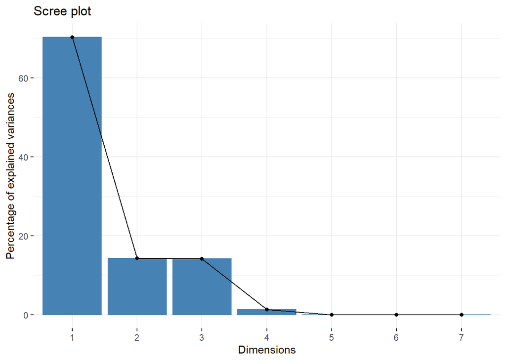

```r
#Visualizing eigenvalues usingscree plot.
library(factoextra)
fviz_eig(df2.pca)
```

The graph shows the percentage variance explained by each principal component.

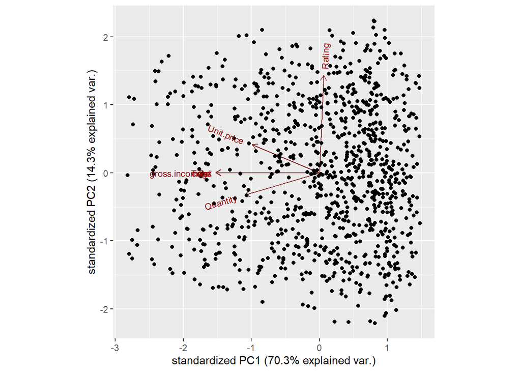

```r
# plotting the two most important principal components to deduce some insights
ggbiplot(df2.pca)
```

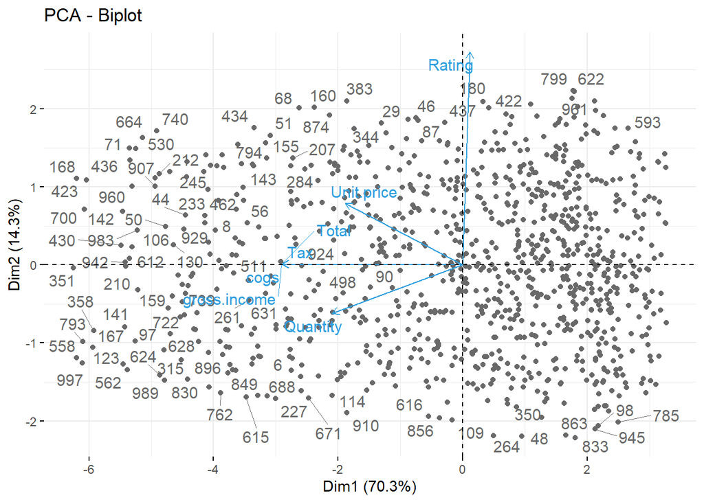

```r
# Adding more detail to the plot by adding idividual variables and plotting using factorextra
#
fviz_pca_biplot(df2.pca, repel = TRUE,
                col.var = "#2E9FDF",
                col.ind = "#696969"
                )
```

This produces a scatter plot with all variables.Variables that are similar are grouped together.

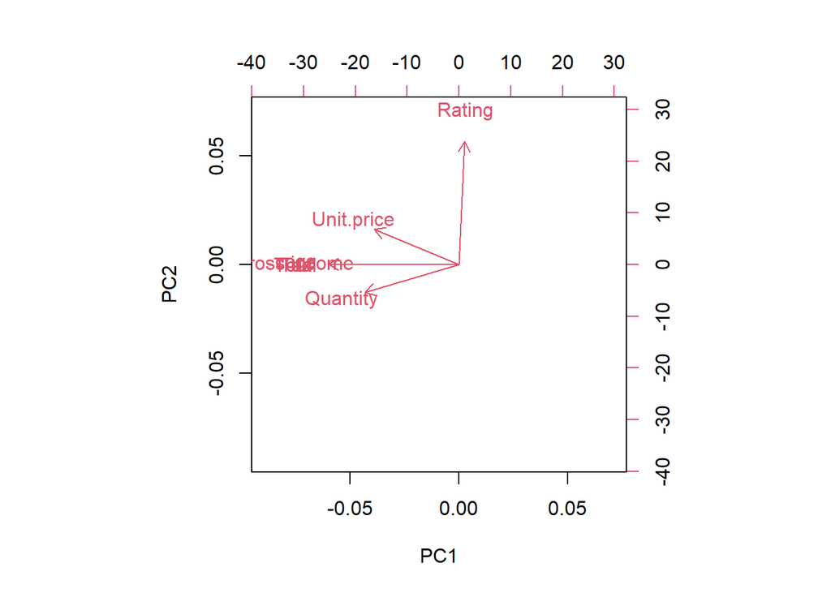

```r
# Hiding the variable values to make it easy to view the vectors
biplot(df2.pca, xlabs = rep("", nrow(df2)))
```

The four principal components are gross income,quantity, unit price and rating.